# Tomey Lab 4 Assignment - Landcover

```r
rm(list=ls())
require(Voss)
require(tidyverse)
require(terra)
require(FedData)
require(sf)
require(tidyterra)
require(landscapemetrics)
require(PerformanceAnalytics)
```

### Setting up NLCD X Study Area

```r
studyArea = st_read('/vsicurl/https://github.com/ValenteJJ/SpatialEcology/raw/main/Week4/studyArea.shp')
```

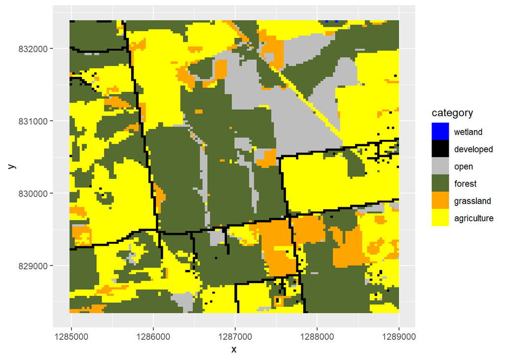

```r
nlcd = get_nlcd(studyArea, label='AlLandscape', year=2011)

# values(nlcd) = as.character(values(nlcd))


nlcdSimple = nlcd
nlcdSimple[nlcdSimple==11] = 1 #Wet areas are a 1 now
nlcdSimple[nlcdSimple %in% c(21, 22, 23, 24)] = 2 #All developed areas are 2
nlcdSimple[nlcdSimple %in% c(31, 52)] = 3 #Barren land and shrub/scrub are 3
nlcdSimple[nlcdSimple %in% c(41,42,43)] = 4 #All forest types are 4
nlcdSimple[nlcdSimple == 71] = 5 #Grassland is 5
nlcdSimple[nlcdSimple %in% c(81,82)] = 6 #And agriculture is 6

#Give these numbers category names
tmp = data.frame('ID' = c(1, 2, 3, 4, 5, 6),
                 'category' = c('wetland', 'developed', 'open', 'forest', 'grassland', 'agriculture'))
nlcdSimple = categories(nlcdSimple, value=tmp)

#And plot the new raster
ggplot(nlcdSimple, aes(x=x, y=y, fill=category)) +
  geom_raster()+
  scale_fill_manual(values=c('blue', 'black', 'gray', 'darkolivegreen', 'orange', 'yellow'))
```

## Challenge 1 (4 points)

**The landscapemetrics package has functions for calculating 12 patch-level metrics. Calculate all 12 of these for every forest patch in our nlcdSimple raster (using the 8-direction rule). This will result in 12 unique values associated with each forest patch. Use the chart.Correlation() function from the PerformanceAnalytics package to examine the correlation among all 12 of these variables.**

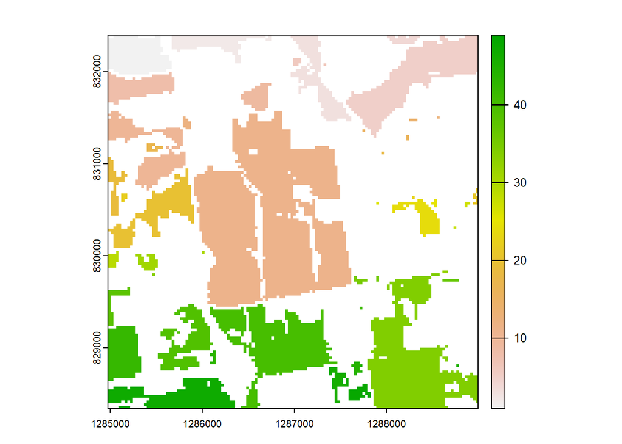

```r
library(landscapemetrics)
library(PerformanceAnalytics)

# Categorizing Forest
forest = nlcdSimple %>%
  setValues(NA)

forest[nlcdSimple ==4] = 1

# Patch IDs
forestPatchId = patches(forest, directions=8, zeroAsNA=T, allowGaps=F)

plot(forestPatchId)
```

```r
################################# METRICS ############################

#1 Patch Area Metric
patchArea = lsm_p_area(forest, directions=8)

patchArea
```

| layer | level | class | id | metric | value |
| --- | --- | --- | --- | --- | --- |
| 1 | patch | 1 | 1 | area | 24.30 |
| 1 | patch | 1 | 2 | area | 15.84 |
| 1 | patch | 1 | 3 | area | 25.29 |
| 1 | patch | 1 | 4 | area | 5.31 |
| 1 | patch | 1 | 5 | area | 25.02 |
| 1 | patch | 1 | 6 | area | 1.71 |
| 1 | patch | 1 | 7 | area | 2.97 |
| 1 | patch | 1 | 8 | area | 18.81 |
| 1 | patch | 1 | 9 | area | 28.17 |
| 1 | patch | 1 | 10 | area | 0.36 |

[output cut: 39 more lines]

```r
#2 Patch Core Metric
patchCore = lsm_p_core(forest, directions=8)

patchCore
```

| layer | level | class | id | metric | value |
| --- | --- | --- | --- | --- | --- |
| 1 | patch | 1 | 1 | core | 18.63 |
| 1 | patch | 1 | 2 | core | 10.26 |
| 1 | patch | 1 | 3 | core | 14.94 |
| 1 | patch | 1 | 4 | core | 1.08 |
| 1 | patch | 1 | 5 | core | 14.76 |
| 1 | patch | 1 | 6 | core | 0.45 |
| 1 | patch | 1 | 7 | core | 0.00 |
| 1 | patch | 1 | 8 | core | 13.86 |
| 1 | patch | 1 | 9 | core | 17.91 |
| 1 | patch | 1 | 10 | core | 0.00 |

[output cut: 39 more lines]

```r
#3 Patch Euclidian Nearest-Neighbor Distance Metric
patchEnn = lsm_p_enn(forest, directions=8)

patchEnn
```

| layer | level | class | id | metric | value |
| --- | --- | --- | --- | --- | --- |
| 1 | patch | 1 | 1 | enn | 60.00000 |
| 1 | patch | 1 | 2 | enn | 60.00000 |
| 1 | patch | 1 | 3 | enn | 60.00000 |
| 1 | patch | 1 | 4 | enn | 60.00000 |
| 1 | patch | 1 | 5 | enn | 60.00000 |
| 1 | patch | 1 | 6 | enn | 60.00000 |
| 1 | patch | 1 | 7 | enn | 60.00000 |
| 1 | patch | 1 | 8 | enn | 60.00000 |
| 1 | patch | 1 | 9 | enn | 60.00000 |
| 1 | patch | 1 | 10 | enn | 60.00000 |

[output cut: 39 more lines]

```r
#4 Patch Perimeter Metric
patchPerim = lsm_p_perim(forest, directions=8)

patchPerim
```

| layer | level | class | id | metric | value |
| --- | --- | --- | --- | --- | --- |
| 1 | patch | 1 | 1 | perim | 2340 |
| 1 | patch | 1 | 2 | perim | 2460 |
| 1 | patch | 1 | 3 | perim | 5400 |
| 1 | patch | 1 | 4 | perim | 1920 |
| 1 | patch | 1 | 5 | perim | 4860 |
| 1 | patch | 1 | 6 | perim | 600 |
| 1 | patch | 1 | 7 | perim | 1380 |
| 1 | patch | 1 | 8 | perim | 1920 |
| 1 | patch | 1 | 9 | perim | 4320 |
| 1 | patch | 1 | 10 | perim | 300 |

[output cut: 39 more lines]

```r
#5 Patch Perimeter-Area Ratio Metric
patchPara = lsm_p_para(forest, directions=8)

patchPara
```

| layer | level | class | id | metric | value |
| --- | --- | --- | --- | --- | --- |
| 1 | patch | 1 | 1 | para | 0.009629630 |
| 1 | patch | 1 | 2 | para | 0.015530303 |
| 1 | patch | 1 | 3 | para | 0.021352313 |
| 1 | patch | 1 | 4 | para | 0.036158192 |
| 1 | patch | 1 | 5 | para | 0.019424460 |
| 1 | patch | 1 | 6 | para | 0.035087719 |
| 1 | patch | 1 | 7 | para | 0.046464646 |
| 1 | patch | 1 | 8 | para | 0.010207337 |
| 1 | patch | 1 | 9 | para | 0.015335463 |
| 1 | patch | 1 | 10 | para | 0.083333333 |

[output cut: 39 more lines]

```r
#6 Patch Corea Area Index Metric
patchCai = lsm_p_cai(forest, directions=8)

patchCai
```

| layer | level | class | id | metric | value |
| --- | --- | --- | --- | --- | --- |
| 1 | patch | 1 | 1 | cai | 76.66667 |
| 1 | patch | 1 | 2 | cai | 64.77273 |
| 1 | patch | 1 | 3 | cai | 59.07473 |
| 1 | patch | 1 | 4 | cai | 20.33898 |
| 1 | patch | 1 | 5 | cai | 58.99281 |
| 1 | patch | 1 | 6 | cai | 26.31579 |
| 1 | patch | 1 | 7 | cai | 0.00000 |
| 1 | patch | 1 | 8 | cai | 73.68421 |
| 1 | patch | 1 | 9 | cai | 63.57827 |
| 1 | patch | 1 | 10 | cai | 0.00000 |

[output cut: 39 more lines]

```r
#7 Patch Perimeter-Area Metric
patchCircle = lsm_p_circle(forest, directions=8)

patchCircle
```

| layer | level | class | id | metric | value |
| --- | --- | --- | --- | --- | --- |
| 1 | patch | 1 | 1 | circle | 0.4711159 |
| 1 | patch | 1 | 2 | circle | 0.6612714 |
| 1 | patch | 1 | 3 | circle | 0.6915528 |
| 1 | patch | 1 | 4 | circle | 0.8356212 |
| 1 | patch | 1 | 5 | circle | 0.7745474 |
| 1 | patch | 1 | 6 | circle | 0.5347779 |
| 1 | patch | 1 | 7 | circle | 0.8383965 |
| 1 | patch | 1 | 8 | circle | 0.4677859 |
| 1 | patch | 1 | 9 | circle | 0.8159243 |
| 1 | patch | 1 | 10 | circle | 0.7004142 |

[output cut: 39 more lines]

```r
#8 Patch Contiguity Index Metric
patchContig = lsm_p_contig(forest, directions=8)

patchContig
```

| layer | level | class | id | metric | value |
| --- | --- | --- | --- | --- | --- |
| 1 | patch | 1 | 1 | contig | 0.9117284 |
| 1 | patch | 1 | 2 | contig | 0.8617424 |
| 1 | patch | 1 | 3 | contig | 0.8196916 |
| 1 | patch | 1 | 4 | contig | 0.6751412 |
| 1 | patch | 1 | 5 | contig | 0.8315348 |
| 1 | patch | 1 | 6 | contig | 0.6842105 |
| 1 | patch | 1 | 7 | contig | 0.5606061 |
| 1 | patch | 1 | 8 | contig | 0.9035088 |
| 1 | patch | 1 | 9 | contig | 0.8610224 |
| 1 | patch | 1 | 10 | contig | 0.2500000 |

[output cut: 39 more lines]

```r
#9 Patch Fractal Dimension Index Metric
patchFrac = lsm_p_frac(forest, directions=8)

patchFrac
```

| layer | level | class | id | metric | value |
| --- | --- | --- | --- | --- | --- |
| 1 | patch | 1 | 1 | frac | 1.027612 |
| 1 | patch | 1 | 2 | frac | 1.072695 |
| 1 | patch | 1 | 3 | frac | 1.158750 |
| 1 | patch | 1 | 4 | frac | 1.134894 |
| 1 | patch | 1 | 5 | frac | 1.142798 |
| 1 | patch | 1 | 6 | frac | 1.028157 |
| 1 | patch | 1 | 7 | frac | 1.134790 |
| 1 | patch | 1 | 8 | frac | 1.016702 |
| 1 | patch | 1 | 9 | frac | 1.113227 |
| 1 | patch | 1 | 10 | frac | 1.054500 |

[output cut: 39 more lines]

```r
#10 Patch Radius of Gyration (Area and Edge) Metric
patchGyrate = lsm_p_gyrate(forest, directions=8)

patchGyrate
```

| layer | level | class | id | metric | value |
| --- | --- | --- | --- | --- | --- |
| 1 | patch | 1 | 1 | gyrate | 196.10382 |
| 1 | patch | 1 | 2 | gyrate | 204.63277 |
| 1 | patch | 1 | 3 | gyrate | 316.11126 |
| 1 | patch | 1 | 4 | gyrate | 160.54682 |
| 1 | patch | 1 | 5 | gyrate | 284.87196 |
| 1 | patch | 1 | 6 | gyrate | 51.48370 |
| 1 | patch | 1 | 7 | gyrate | 141.06460 |
| 1 | patch | 1 | 8 | gyrate | 173.87804 |
| 1 | patch | 1 | 9 | gyrate | 333.13661 |
| 1 | patch | 1 | 10 | gyrate | 30.00000 |

[output cut: 39 more lines]

```r
#11 Patch Number of Core Areas Metric
patchNcore = lsm_p_ncore(forest, directions=8)

patchNcore
```

| layer | level | class | id | metric | value |
| --- | --- | --- | --- | --- | --- |
| 1 | patch | 1 | 1 | ncore | 1 |
| 1 | patch | 1 | 2 | ncore | 1 |
| 1 | patch | 1 | 3 | ncore | 3 |
| 1 | patch | 1 | 4 | ncore | 2 |
| 1 | patch | 1 | 5 | ncore | 3 |
| 1 | patch | 1 | 6 | ncore | 1 |
| 1 | patch | 1 | 7 | ncore | 0 |
| 1 | patch | 1 | 8 | ncore | 1 |
| 1 | patch | 1 | 9 | ncore | 2 |
| 1 | patch | 1 | 10 | ncore | 0 |

[output cut: 39 more lines]

```r
#12 Patch Shape Metric
patchShape = lsm_p_shape(forest, directions=8)

patchShape
```

| layer | level | class | id | metric | value |
| --- | --- | --- | --- | --- | --- |
| 1 | patch | 1 | 1 | shape | 1.186732 |
| 1 | patch | 1 | 2 | shape | 1.545246 |
| 1 | patch | 1 | 3 | shape | 2.684475 |
| 1 | patch | 1 | 4 | shape | 2.083023 |
| 1 | patch | 1 | 5 | shape | 2.429029 |
| 1 | patch | 1 | 6 | shape | 1.147079 |
| 1 | patch | 1 | 7 | shape | 2.001893 |
| 1 | patch | 1 | 8 | shape | 1.106743 |
| 1 | patch | 1 | 9 | shape | 2.034840 |
| 1 | patch | 1 | 10 | shape | 1.250000 |

[output cut: 39 more lines]

```r
###################### CORRELATION CHART ####################
patch_metrics <- data.frame(
  PatchArea = patchArea,
  PatchCore = patchCore,
  PatchEnn = patchEnn,
  PatchPerim = patchPerim,
  PatchPara = patchPara,
  PatchCai = patchCai,
  PatchCircle = patchCircle,
  PatchContig = patchContig,
  PatchFrac = patchFrac,
  PatchGyrate = patchGyrate,
  PatchNcore = patchNcore,
  PatchShape = patchShape
)

head(patch_metrics)
```

|  | PatchArea.layer | PatchArea.level | PatchArea.class | PatchArea.id | PatchArea.metric | PatchArea.value | PatchCore.layer | PatchCore.level | PatchCore.class | PatchCore.id | PatchCore.metric | PatchCore.value | PatchEnn.layer | PatchEnn.level | PatchEnn.class | PatchEnn.id | PatchEnn.metric | PatchEnn.value | PatchPerim.layer | PatchPerim.level | PatchPerim.class | PatchPerim.id | PatchPerim.metric | PatchPerim.value | PatchPara.layer | PatchPara.level | PatchPara.class | PatchPara.id | PatchPara.metric | … |
| --- | --- | --- | --- | --- | --- | --- | --- | --- | --- | --- | --- | --- | --- | --- | --- | --- | --- | --- | --- | --- | --- | --- | --- | --- | --- | --- | --- | --- | --- | --- |
| 1 | 1 | patch | 1 | 1 | area | 24.30 | 1 | patch | 1 | 1 | core | 18.63 | 1 | patch | 1 | 1 | enn | 60 | 1 | patch | 1 | 1 | perim | 2340 | 1 | patch | 1 | 1 | para | … |
| 2 | 1 | patch | 1 | 2 | area | 15.84 | 1 | patch | 1 | 2 | core | 10.26 | 1 | patch | 1 | 2 | enn | 60 | 1 | patch | 1 | 2 | perim | 2460 | 1 | patch | 1 | 2 | para | … |
| 3 | 1 | patch | 1 | 3 | area | 25.29 | 1 | patch | 1 | 3 | core | 14.94 | 1 | patch | 1 | 3 | enn | 60 | 1 | patch | 1 | 3 | perim | 5400 | 1 | patch | 1 | 3 | para | … |
| 4 | 1 | patch | 1 | 4 | area | 5.31 | 1 | patch | 1 | 4 | core | 1.08 | 1 | patch | 1 | 4 | enn | 60 | 1 | patch | 1 | 4 | perim | 1920 | 1 | patch | 1 | 4 | para | … |
| 5 | 1 | patch | 1 | 5 | area | 25.02 | 1 | patch | 1 | 5 | core | 14.76 | 1 | patch | 1 | 5 | enn | 60 | 1 | patch | 1 | 5 | perim | 4860 | 1 | patch | 1 | 5 | para | … |
| 6 | 1 | patch | 1 | 6 | area | 1.71 | 1 | patch | 1 | 6 | core | 0.45 | 1 | patch | 1 | 6 | enn | 60 | 1 | patch | 1 | 6 | perim | 600 | 1 | patch | 1 | 6 | para | … |

[output not shown]

[output cut: 100 more lines]

[output not shown]

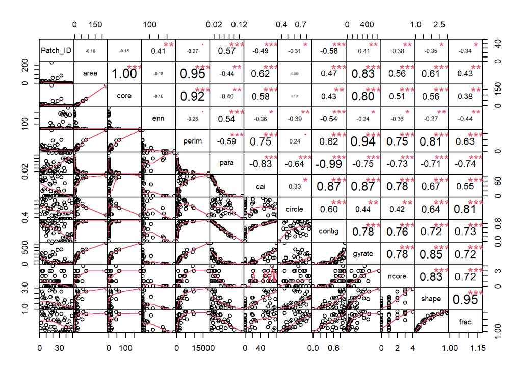

```r
write.csv(patch_metrics, "patch_metrics.csv", row.names = TRUE)

pmetric <- read.csv('https://raw.githubusercontent.com/rytomey/WILD7970_Spatial/main/W4_LC__patterns_movements/patch_metrics.csv')

pmetric %>%
  as.data.frame() %>%
  PerformanceAnalytics::chart.Correlation(histogram=F)
```

##### What patterns do you notice, and what do they tell you about the uniqueness or redundancy of the patch-level metrics you calculated?

From the correlation chart, I can see that some of the patch metrics are negatively correlated with one another, while others are positively correlation with one another. Patch metrics including ‘shape/frac’, ‘area/core’, and ‘contig/para’ are very strongly correlated (positive or negative), while there are several metrics that are not significantly correlated, such as ‘circle/core’. Although the use of all 12 patch metrics may provide redundant information, the use several metrics should provide unique information about different patches.

## Challenge 2 (4 points)

**In our lab, we used the 8-direction or “queen” rule to delineate patches. Using the nlcdSimple raster we created, explore the differences in patch characteristics if you were to use the 4-direction or “rook” rule for delineating patches. Calculate the following class-level metrics for forest cover for both the queen and rook patch delineation rules: number of patches, mean patch size, standard deviation in patch size, nearest-neighbor distance, and total edge length.**

```r
classCats = data.frame('class' = c(1, 2, 3, 4, 5, 6),
                 'category' = c('wetland', 'developed', 'open', 'forest', 'grassland', 'agriculture'))

################################ QUEEN ###############################

# Number of Patches
lsm_c_np(nlcdSimple, directions=8) %>%
  left_join(classCats, by='class')
```

| layer | level | class | id | metric | value | category |
| --- | --- | --- | --- | --- | --- | --- |
| 1 | class | 1 | NA | np | 2 | wetland |
| 1 | class | 2 | NA | np | 51 | developed |
| 1 | class | 3 | NA | np | 59 | open |
| 1 | class | 4 | NA | np | 49 | forest |
| 1 | class | 5 | NA | np | 59 | grassland |
| 1 | class | 6 | NA | np | 59 | agriculture |

```r
# Mean Patch Size
lsm_c_area_mn(nlcdSimple, directions=8) %>%
  left_join(classCats, by='class')
```

| layer | level | class | id | metric | value | category |
| --- | --- | --- | --- | --- | --- | --- |
| 1 | class | 1 | NA | area_mn | 0.090000 | wetland |
| 1 | class | 2 | NA | area_mn | 1.138235 | developed |
| 1 | class | 3 | NA | area_mn | 2.962373 | open |
| 1 | class | 4 | NA | area_mn | 13.650612 | forest |
| 1 | class | 5 | NA | area_mn | 2.240847 | grassland |
| 1 | class | 6 | NA | area_mn | 10.067797 | agriculture |

```r
# Stand Deviation in Patch Size
lsm_c_area_sd(nlcdSimple, directions=8) %>%
  left_join(classCats, by='class')
```

| layer | level | class | id | metric | value | category |
| --- | --- | --- | --- | --- | --- | --- |
| 1 | class | 1 | NA | area_sd | 0.000000 | wetland |
| 1 | class | 2 | NA | area_sd | 7.140984 | developed |
| 1 | class | 3 | NA | area_sd | 11.691167 | open |
| 1 | class | 4 | NA | area_sd | 35.959160 | forest |
| 1 | class | 5 | NA | area_sd | 4.642781 | grassland |
| 1 | class | 6 | NA | area_sd | 26.473516 | agriculture |

```r
# Nearest-Neighbor Distance
lsm_c_enn_mn(nlcdSimple, directions=8) %>%
  left_join(classCats, by='class')
```

| layer | level | class | id | metric | value | category |
| --- | --- | --- | --- | --- | --- | --- |
| 1 | class | 1 | NA | enn_mn | 120.00000 | wetland |
| 1 | class | 2 | NA | enn_mn | 109.01191 | developed |
| 1 | class | 3 | NA | enn_mn | 147.94124 | open |
| 1 | class | 4 | NA | enn_mn | 83.78503 | forest |
| 1 | class | 5 | NA | enn_mn | 156.36138 | grassland |
| 1 | class | 6 | NA | enn_mn | 86.89419 | agriculture |

```r
# Total Edge Length
lsm_c_te(nlcdSimple, directions=8) %>%
  left_join(classCats, by='class')
```

| layer | level | class | id | metric | value | category |
| --- | --- | --- | --- | --- | --- | --- |
| 1 | class | 1 | NA | te | 180 | wetland |
| 1 | class | 2 | NA | te | 41160 | developed |
| 1 | class | 3 | NA | te | 37350 | open |
| 1 | class | 4 | NA | te | 88740 | forest |
| 1 | class | 5 | NA | te | 40320 | grassland |
| 1 | class | 6 | NA | te | 86910 | agriculture |

```r
############################### ROOK #################################
# Number of Patches
lsm_c_np(nlcdSimple, directions=4) %>%
  left_join(classCats, by='class')
```

| layer | level | class | id | metric | value | category |
| --- | --- | --- | --- | --- | --- | --- |
| 1 | class | 1 | NA | np | 2 | wetland |
| 1 | class | 2 | NA | np | 57 | developed |
| 1 | class | 3 | NA | np | 82 | open |
| 1 | class | 4 | NA | np | 67 | forest |
| 1 | class | 5 | NA | np | 71 | grassland |
| 1 | class | 6 | NA | np | 80 | agriculture |

```r
# Mean Patch Size
lsm_c_area_mn(nlcdSimple, directions=4) %>%
  left_join(classCats, by='class')
```

| layer | level | class | id | metric | value | category |
| --- | --- | --- | --- | --- | --- | --- |
| 1 | class | 1 | NA | area_mn | 0.090000 | wetland |
| 1 | class | 2 | NA | area_mn | 1.018421 | developed |
| 1 | class | 3 | NA | area_mn | 2.131463 | open |
| 1 | class | 4 | NA | area_mn | 9.983284 | forest |
| 1 | class | 5 | NA | area_mn | 1.862113 | grassland |
| 1 | class | 6 | NA | area_mn | 7.425000 | agriculture |

```r
# Stand Deviation in Patch Size
lsm_c_area_sd(nlcdSimple, directions=4) %>%
  left_join(classCats, by='class')
```

| layer | level | class | id | metric | value | category |
| --- | --- | --- | --- | --- | --- | --- |
| 1 | class | 1 | NA | area_sd | 0.000000 | wetland |
| 1 | class | 2 | NA | area_sd | 6.720001 | developed |
| 1 | class | 3 | NA | area_sd | 9.969312 | open |
| 1 | class | 4 | NA | area_sd | 24.119895 | forest |
| 1 | class | 5 | NA | area_sd | 4.292068 | grassland |
| 1 | class | 6 | NA | area_sd | 20.916728 | agriculture |

```r
# Nearest-Neighbor Distance
lsm_c_enn_mn(nlcdSimple, directions=4) %>%
  left_join(classCats, by='class')
```

| layer | level | class | id | metric | value | category |
| --- | --- | --- | --- | --- | --- | --- |
| 1 | class | 1 | NA | enn_mn | 120.00000 | wetland |
| 1 | class | 2 | NA | enn_mn | 98.64707 | developed |
| 1 | class | 3 | NA | enn_mn | 104.29005 | open |
| 1 | class | 4 | NA | enn_mn | 69.48852 | forest |
| 1 | class | 5 | NA | enn_mn | 128.68258 | grassland |
| 1 | class | 6 | NA | enn_mn | 72.43003 | agriculture |

```r
# Total Edge Length
lsm_c_te(nlcdSimple, directions=4) %>%
  left_join(classCats, by='class')
```

| layer | level | class | id | metric | value | category |
| --- | --- | --- | --- | --- | --- | --- |
| 1 | class | 1 | NA | te | 180 | wetland |
| 1 | class | 2 | NA | te | 41160 | developed |
| 1 | class | 3 | NA | te | 37350 | open |
| 1 | class | 4 | NA | te | 88740 | forest |
| 1 | class | 5 | NA | te | 40320 | grassland |
| 1 | class | 6 | NA | te | 86910 | agriculture |

## Challenge 3 (4 points)

**Using the same zoomed-in study area that we used in the lab, download NLCD raster data for the years 2001 and 2019 and simplify these rasters into 6 landcover categories (wet, developed, barren, forest, grassland, and agriculture). Plot these two rasters.**

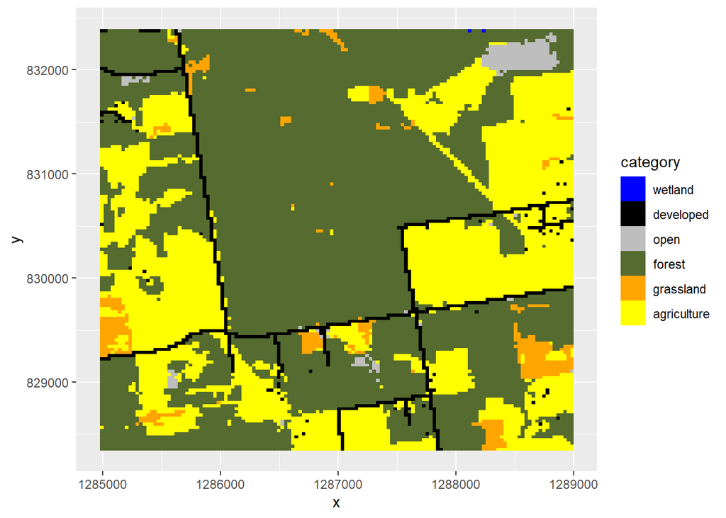

```r
##################################### 2001 #####################################
nlcd01 = get_nlcd(studyArea, label='AlLandscape', year=2001)

# values(nlcd) = as.character(values(nlcd))


nlcdSimple01 = nlcd01
nlcdSimple01[nlcdSimple01==11] = 1 #Wet areas are a 1 now
nlcdSimple01[nlcdSimple01 %in% c(21, 22, 23, 24)] = 2 #All developed areas are 2
nlcdSimple01[nlcdSimple01 %in% c(31, 52)] = 3 #Barren land and shrub/scrub are 3
nlcdSimple01[nlcdSimple01 %in% c(41,42,43)] = 4 #All forest types are 4
nlcdSimple01[nlcdSimple01 == 71] = 5 #Grassland is 5
nlcdSimple01[nlcdSimple01 %in% c(81,82)] = 6 #And agriculture is 6

#Give these numbers category names
tmp = data.frame('ID' = c(1, 2, 3, 4, 5, 6),
                 'category' = c('wetland', 'developed', 'open', 'forest', 'grassland', 'agriculture'))
nlcdSimple01 = categories(nlcdSimple01, value=tmp)

#And plot the new raster
ggplot(nlcdSimple01, aes(x=x, y=y, fill=category)) +
  geom_raster()+
  scale_fill_manual(values=c('blue', 'black', 'gray', 'darkolivegreen', 'orange', 'yellow'))
```

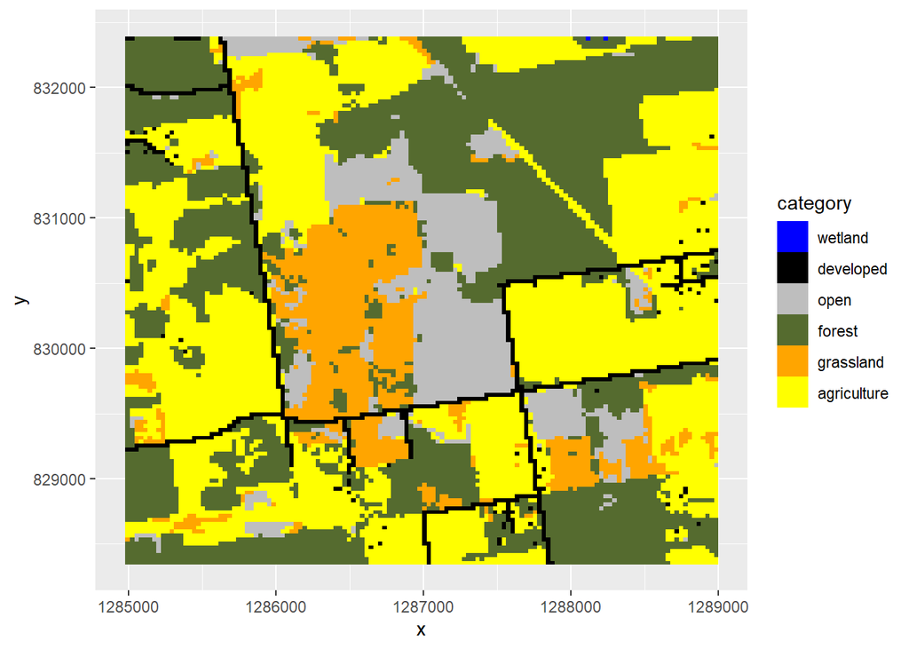

```r
############################### 2019 ###########################################

nlcd19 = get_nlcd(studyArea, label='AlLandscape', year=2019)

# values(nlcd) = as.character(values(nlcd))


nlcdSimple19 = nlcd19
nlcdSimple19[nlcdSimple19==11] = 1 #Wet areas are a 1 now
nlcdSimple19[nlcdSimple19 %in% c(21, 22, 23, 24)] = 2 #All developed areas are 2
nlcdSimple19[nlcdSimple19 %in% c(31, 52)] = 3 #Barren land and shrub/scrub are 3
nlcdSimple19[nlcdSimple19 %in% c(41,42,43)] = 4 #All forest types are 4
nlcdSimple19[nlcdSimple19 == 71] = 5 #Grassland is 5
nlcdSimple19[nlcdSimple19 %in% c(81,82)] = 6 #And agriculture is 6

tmp = data.frame('ID' = c(1, 2, 3, 4, 5, 6),
                 'category' = c('wetland', 'developed', 'open', 'forest', 'grassland', 'agriculture'))
nlcdSimple19 = categories(nlcdSimple19, value=tmp)

ggplot(nlcdSimple19, aes(x=x, y=y, fill=category)) +
  geom_raster()+
  scale_fill_manual(values=c('blue', 'black', 'gray', 'darkolivegreen', 'orange', 'yellow'))
```

#### What are some of the initial changes you notice between 2001 and 2019?

A major change from 2001 to 2019 is the decrease in forest cover and increase of agricultural, open, and grassland cover between the years. It appears that in the maps, the larger areas of forest cover seen in 2001 become fragmented areas of various land cover types in 2019. There appears to be both habitat fragmentation and loss in terms of forest cover between the years. While there is more grassland, agriculture, and open cover in 2019 and 2001, the patches of these land cover categories from 2001 appear to be more fragmented.

**Quantify this at the class level by calculating and reporting the changes in (1) the total amount of each land cover type (2) mean patch size for each land cover type, and (3) mean nearest neighbor distance for each cover type between the years 2011 and 2019.**

```r
########################### 2011 ######################################
# Total Amount of Each Land Cover Type
lsm_c_ca(nlcdSimple, directions=8)
```

| layer | level | class | id | metric | value |
| --- | --- | --- | --- | --- | --- |
| 1 | class | 1 | NA | ca | 0.18 |
| 1 | class | 2 | NA | ca | 58.05 |
| 1 | class | 3 | NA | ca | 174.78 |
| 1 | class | 4 | NA | ca | 668.88 |
| 1 | class | 5 | NA | ca | 132.21 |
| 1 | class | 6 | NA | ca | 594.00 |

```r
# Mean Patch Size for Each Land Cover Type
lsm_c_area_mn(nlcdSimple, directions=8)
```

| layer | level | class | id | metric | value |
| --- | --- | --- | --- | --- | --- |
| 1 | class | 1 | NA | area_mn | 0.090000 |
| 1 | class | 2 | NA | area_mn | 1.138235 |
| 1 | class | 3 | NA | area_mn | 2.962373 |
| 1 | class | 4 | NA | area_mn | 13.650612 |
| 1 | class | 5 | NA | area_mn | 2.240847 |
| 1 | class | 6 | NA | area_mn | 10.067797 |

```r
# Mean Nearest Neighbor Distance for Each Cover Type
lsm_c_enn_mn(nlcdSimple, directions=8)
```

| layer | level | class | id | metric | value |
| --- | --- | --- | --- | --- | --- |
| 1 | class | 1 | NA | enn_mn | 120.00000 |
| 1 | class | 2 | NA | enn_mn | 109.01191 |
| 1 | class | 3 | NA | enn_mn | 147.94124 |
| 1 | class | 4 | NA | enn_mn | 83.78503 |
| 1 | class | 5 | NA | enn_mn | 156.36138 |
| 1 | class | 6 | NA | enn_mn | 86.89419 |

```r
########################### 2019 #######################################
# Total Amount of Each Land Cover Type
lsm_c_ca(nlcdSimple19, directions=8)
```

| layer | level | class | id | metric | value |
| --- | --- | --- | --- | --- | --- |
| 1 | class | 1 | NA | ca | 0.18 |
| 1 | class | 2 | NA | ca | 58.05 |
| 1 | class | 3 | NA | ca | 181.71 |
| 1 | class | 4 | NA | ca | 584.28 |
| 1 | class | 5 | NA | ca | 176.40 |
| 1 | class | 6 | NA | ca | 627.48 |

```r
# Mean Patch Size for Each Land Cover Type
lsm_c_area_mn(nlcdSimple19, directions=8)
```

| layer | level | class | id | metric | value |
| --- | --- | --- | --- | --- | --- |
| 1 | class | 1 | NA | area_mn | 0.090000 |
| 1 | class | 2 | NA | area_mn | 1.138235 |
| 1 | class | 3 | NA | area_mn | 3.708367 |
| 1 | class | 4 | NA | area_mn | 7.213333 |
| 1 | class | 5 | NA | area_mn | 3.458824 |
| 1 | class | 6 | NA | area_mn | 14.592558 |

```r
# Mean Nearest Neighbor Distance for Each Cover Type
lsm_c_enn_mn(nlcdSimple19, directions=8)
```

| layer | level | class | id | metric | value |
| --- | --- | --- | --- | --- | --- |
| 1 | class | 1 | NA | enn_mn | 120.00000 |
| 1 | class | 2 | NA | enn_mn | 109.01191 |
| 1 | class | 3 | NA | enn_mn | 185.70648 |
| 1 | class | 4 | NA | enn_mn | 86.93495 |
| 1 | class | 5 | NA | enn_mn | 152.81415 |
| 1 | class | 6 | NA | enn_mn | 96.78168 |

#### Give a short description of how you interpret the changes in these values.

Wet areas = 1 - All developed areas = 2 - Barren land and shrub/scrub = 3 - All forest types = 4 - Grassland = 5 - agriculture = 6 Total Amount of each land cover: 3,5,6 = increase, 4=decrease. While the total area of the forest class decreases, the area of the barren/shrub, grassland, and agricultural land cover classification increases from 2011 to 2019. mean patch size: 3,5,6 = increase, 4 = decrease From 2011 - 2019, the average size of each patch increases for the barren/shrub, grassland, and agricultural land cover categories, while it decreases for the forest land cover category. mean nearest neighbor distance: 3,4,6 = increase, 5=decrease The average distance to the nearest patch neighbor increases for barren/shrub, forest, and agriculture and decreases for grassland from 2011 to 2019.

**Quantify these changes at the landscape level by calculating and reporting on changes in the (1) Shannon diversity and (2) Shannon evenness of the landscapes at the different time points.**

```r
########################### 2011 #######################################

# Shannon Diversity
lsm_l_shdi(nlcdSimple)
```

| layer | level | class | id | metric | value |
| --- | --- | --- | --- | --- | --- |
| 1 | landscape | NA | NA | shdi | 1.296666 |

```r
# Shannon Evenness
lsm_l_shei(nlcdSimple)
```

| layer | level | class | id | metric | value |
| --- | --- | --- | --- | --- | --- |
| 1 | landscape | NA | NA | shei | 0.7236833 |

```r
########################### 2019 #######################################
# Shannon Diversity
lsm_l_shdi(nlcdSimple19)
```

| layer | level | class | id | metric | value |
| --- | --- | --- | --- | --- | --- |
| 1 | landscape | NA | NA | shdi | 1.340636 |

```r
# Shannon Evenness
lsm_l_shei(nlcdSimple19)
```

| layer | level | class | id | metric | value |
| --- | --- | --- | --- | --- | --- |
| 1 | landscape | NA | NA | shei | 0.7482231 |

#### Give a short description of how you interpret the changes in these values.

Both the Shannon Diversity index and the Shannon Evenness index increase from 2011 to 2019. This suggests that the diversity and evenness of the landcover types spread out across a landscape increases between 2011 and 2019. An increase in both metrics is likely due to the fact that patches of land cover such as grassland, barren/shrub, and agriculture increase and are distributed throughout more of the study area/landscape in 2019 compared to 2011.

## Challenge 4 (4 points)

**Use the voss2d() function to simulate a surface where g = 7 and H = 0.5. From that, create 9 ‘landscapes’ with 10%, 20%, 30%, …, 90% threshold values. The ‘1’ values here can represent anything your imagination comes up with. It could be forest cover, cover of some other land cover type, bodies of water, temperatures above a threshold, etc. I suggest you set the seed for your simulation value so that you get the same outcome each time you run the code. Plot these landscapes.**

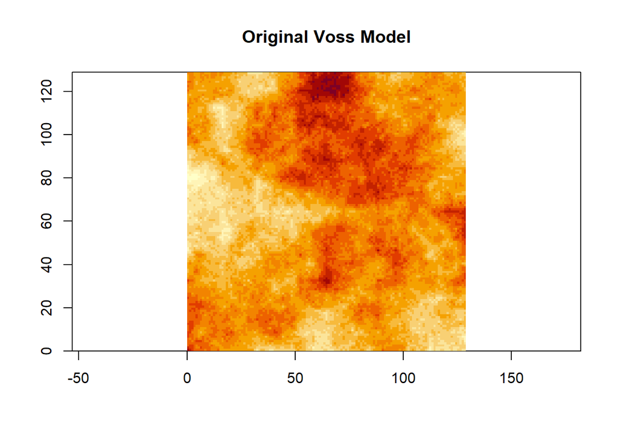

```r
set.seed(23)

vossModel = voss2d(g = 7, H = 0.5)
vossModel = rast(vossModel$z)
image(vossModel, main = "Original Voss Model")
```

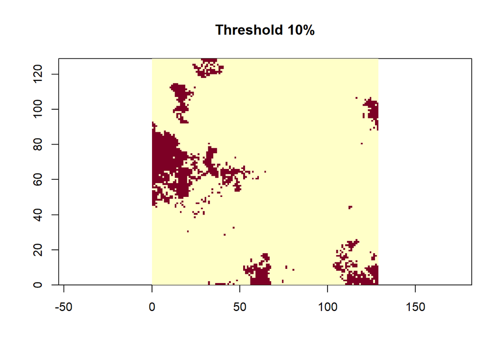

```r
# 10%
threshold10 = quantile(as.matrix(vossModel), prob = 0.1)
voss10 = ifel(vossModel > threshold10, 0, 1)
image(voss10, main = "Threshold 10%")
```

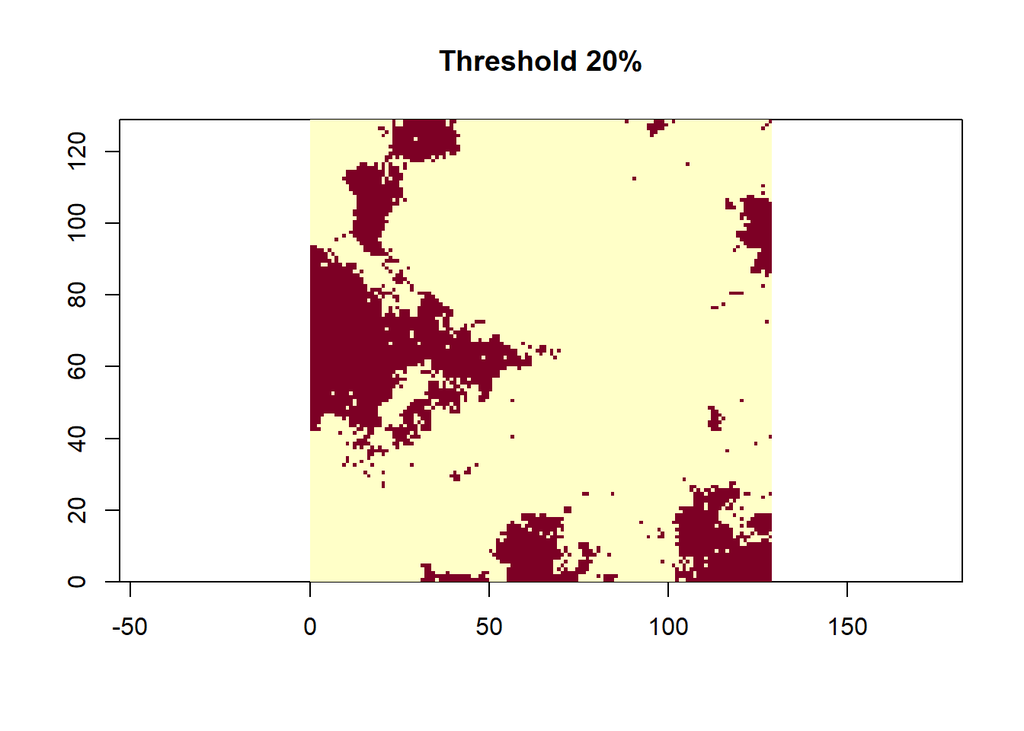

```r
# 20%
threshold20 = quantile(as.matrix(vossModel), prob = 0.2)
voss20 = ifel(vossModel > threshold20, 0, 1)
image(voss20, main = "Threshold 20%")
```

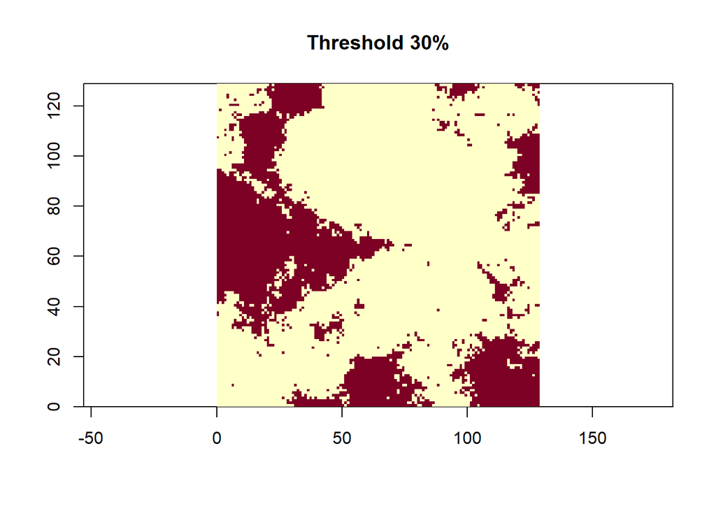

```r
# 30%
threshold30 = quantile(as.matrix(vossModel), prob = 0.3)
voss30 = ifel(vossModel > threshold30, 0, 1)
image(voss30, main = "Threshold 30%")
```

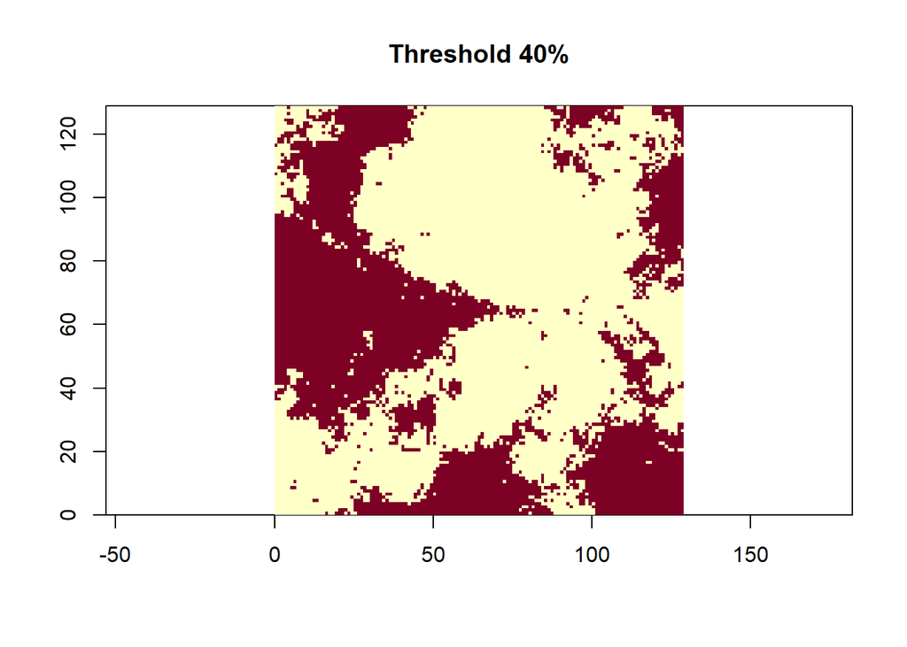

```r
# 40%
threshold40 = quantile(as.matrix(vossModel), prob = 0.4)
voss40 = ifel(vossModel > threshold40, 0, 1)
image(voss40, main = "Threshold 40%")
```

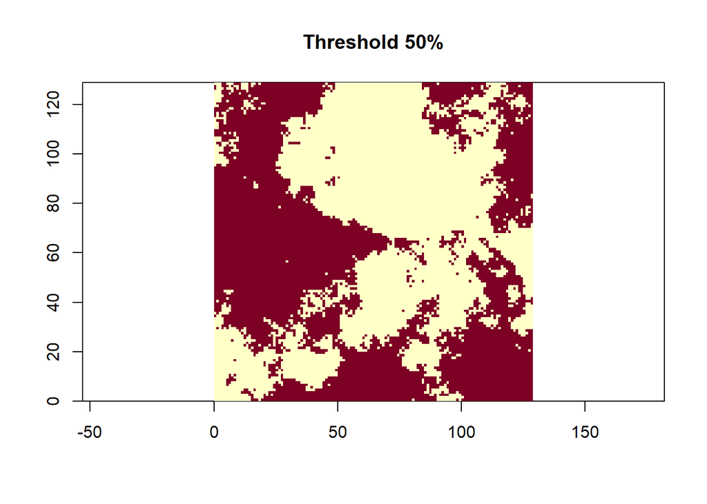

```r
# 50%
threshold50 = quantile(as.matrix(vossModel), prob = 0.5)
voss50 = ifel(vossModel > threshold50, 0, 1)
image(voss50, main = "Threshold 50%")
```

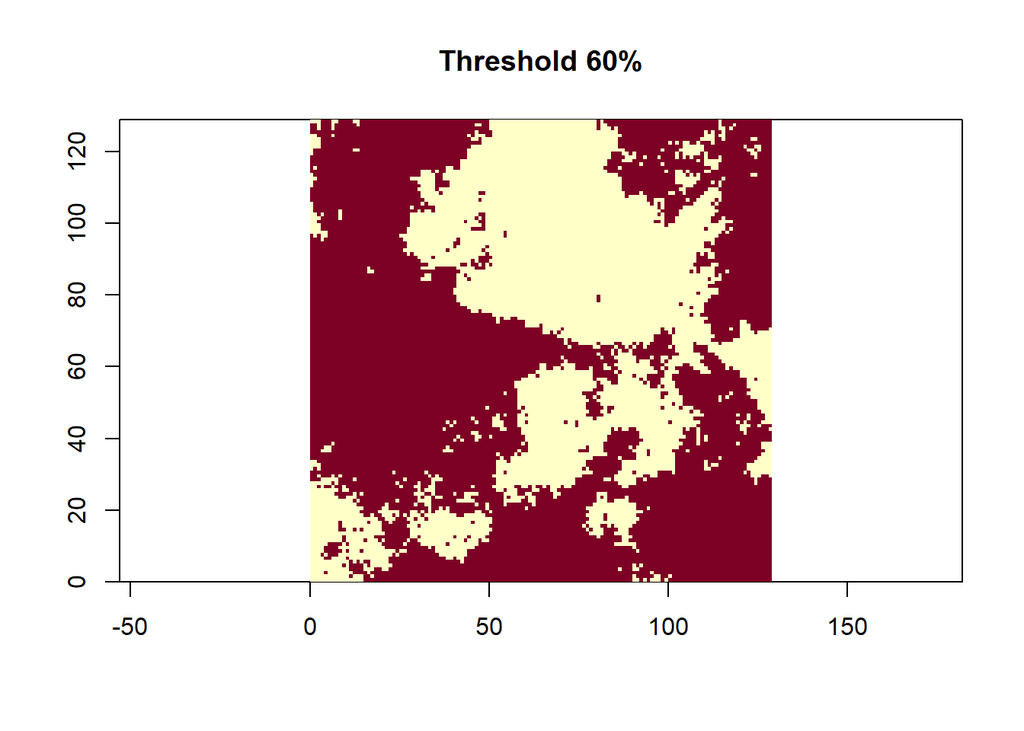

```r
# 60%
threshold60 = quantile(as.matrix(vossModel), prob = 0.6)
voss60 = ifel(vossModel > threshold60, 0, 1)
image(voss60, main = "Threshold 60%")
```

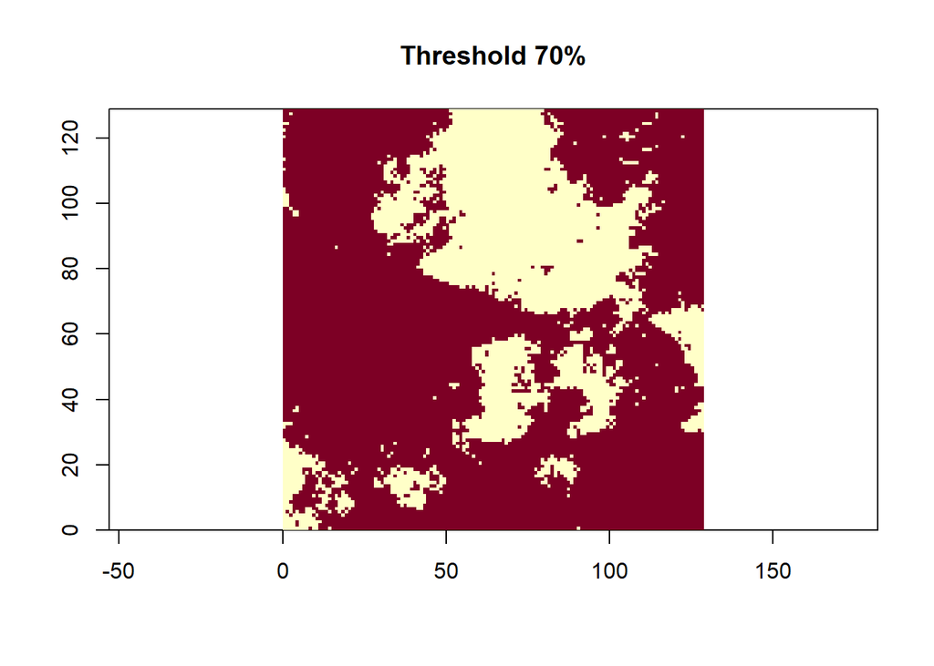

```r
# 70%
threshold70 = quantile(as.matrix(vossModel), prob = 0.7)
voss70 = ifel(vossModel > threshold70, 0, 1)
image(voss70, main = "Threshold 70%")
```

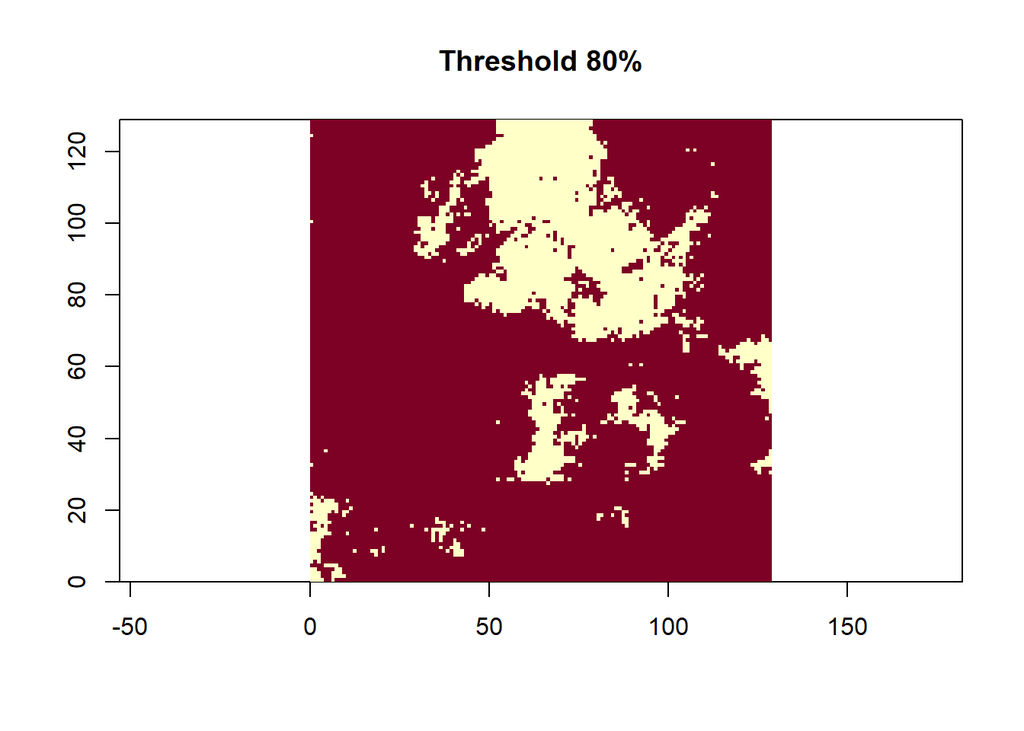

```r
# 80%
threshold80 = quantile(as.matrix(vossModel), prob = 0.8)
voss80 = ifel(vossModel > threshold80, 0, 1)
image(voss80, main = "Threshold 80%")
```

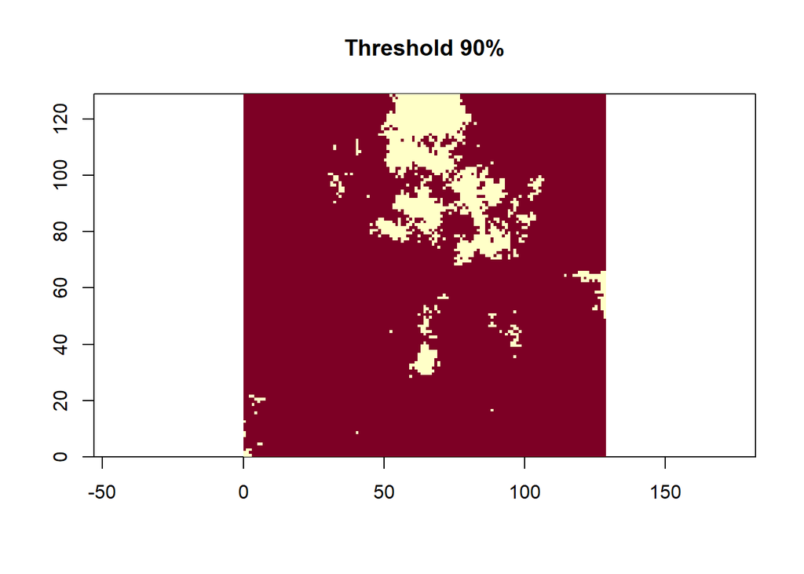

```r
# 90%
threshold90 = quantile(as.matrix(vossModel), prob = 0.9)
voss90 = ifel(vossModel > threshold90, 0, 1)
image(voss90, main = "Threshold 90%")
```

#### Comment on what patterns you see changing as the value increases from a 10% cover to 90% cover

The cover areas that are present in 10% grow as the value of cover increases. It appears that the higher the cover value, the patches become less aggregated and there are less patches overall. As the cover increases in the study area, the areas gaining cover are dispersed evenly thoughout the study area.

**Identify 3 class-level or landscape-level metrics that help you capture the changes you are observing. Calculate those metrics for each of the 9 landscapes and plot them (x-axis is threshold value and y-axis is calculated metric).**

```r
# 10
lsm_l_area_mn(voss10, directions=8)
```

| layer | level | class | id | metric | value |
| --- | --- | --- | --- | --- | --- |
| 1 | landscape | NA | NA | area_mn | 0.01935 |

```r
lsm_l_np(voss10, directions=8)
```

| layer | level | class | id | metric | value |
| --- | --- | --- | --- | --- | --- |
| 1 | landscape | NA | NA | np | 86 |

```r
lsm_l_division(voss10, directions=8)
```

| layer | level | class | id | metric | value |
| --- | --- | --- | --- | --- | --- |
| 1 | landscape | NA | NA | division | 0.1933848 |

```r
# 20
lsm_l_area_mn(voss20, directions=8)
```

| layer | level | class | id | metric | value |
| --- | --- | --- | --- | --- | --- |
| 1 | landscape | NA | NA | area_mn | 0.01615631 |

```r
lsm_l_np(voss20, directions=8)
```

| layer | level | class | id | metric | value |
| --- | --- | --- | --- | --- | --- |
| 1 | landscape | NA | NA | np | 103 |

```r
lsm_l_division(voss20, directions=8)
```

| layer | level | class | id | metric | value |
| --- | --- | --- | --- | --- | --- |
| 1 | landscape | NA | NA | division | 0.3524663 |

```r
# 30
lsm_l_area_mn(voss30, directions=8)
```

| layer | level | class | id | metric | value |
| --- | --- | --- | --- | --- | --- |
| 1 | landscape | NA | NA | area_mn | 0.01155625 |

```r
lsm_l_np(voss30, directions=8)
```

| layer | level | class | id | metric | value |
| --- | --- | --- | --- | --- | --- |
| 1 | landscape | NA | NA | np | 144 |

```r
lsm_l_division(voss30, directions=8)
```

| layer | level | class | id | metric | value |
| --- | --- | --- | --- | --- | --- |
| 1 | landscape | NA | NA | division | 0.5263107 |

```r
# 40
lsm_l_area_mn(voss40, directions=8)
```

| layer | level | class | id | metric | value |
| --- | --- | --- | --- | --- | --- |
| 1 | landscape | NA | NA | area_mn | 0.0102092 |

```r
lsm_l_np(voss40, directions=8)
```

| layer | level | class | id | metric | value |
| --- | --- | --- | --- | --- | --- |
| 1 | landscape | NA | NA | np | 163 |

```r
lsm_l_division(voss40, directions=8)
```

| layer | level | class | id | metric | value |
| --- | --- | --- | --- | --- | --- |
| 1 | landscape | NA | NA | division | 0.6142139 |

```r
# 50
lsm_l_area_mn(voss50, directions=8)
```

| layer | level | class | id | metric | value |
| --- | --- | --- | --- | --- | --- |
| 1 | landscape | NA | NA | area_mn | 0.01232667 |

```r
lsm_l_np(voss50, directions=8)
```

| layer | level | class | id | metric | value |
| --- | --- | --- | --- | --- | --- |
| 1 | landscape | NA | NA | np | 135 |

```r
lsm_l_division(voss50, directions=8)
```

| layer | level | class | id | metric | value |
| --- | --- | --- | --- | --- | --- |
| 1 | landscape | NA | NA | division | 0.6520009 |

```r
# 60
lsm_l_area_mn(voss60, directions=8)
```

| layer | level | class | id | metric | value |
| --- | --- | --- | --- | --- | --- |
| 1 | landscape | NA | NA | area_mn | 0.01147655 |

```r
lsm_l_np(voss60, directions=8)
```

| layer | level | class | id | metric | value |
| --- | --- | --- | --- | --- | --- |
| 1 | landscape | NA | NA | np | 145 |

```r
lsm_l_division(voss60, directions=8)
```

| layer | level | class | id | metric | value |
| --- | --- | --- | --- | --- | --- |
| 1 | landscape | NA | NA | division | 0.6307496 |

```r
# 70
lsm_l_area_mn(voss70, directions=8)
```

| layer | level | class | id | metric | value |
| --- | --- | --- | --- | --- | --- |
| 1 | landscape | NA | NA | area_mn | 0.01459737 |

```r
lsm_l_np(voss70, directions=8)
```

| layer | level | class | id | metric | value |
| --- | --- | --- | --- | --- | --- |
| 1 | landscape | NA | NA | np | 114 |

```r
lsm_l_division(voss70, directions=8)
```

| layer | level | class | id | metric | value |
| --- | --- | --- | --- | --- | --- |
| 1 | landscape | NA | NA | division | 0.4831203 |

```r
# 80
lsm_l_area_mn(voss80, directions=8)
```

| layer | level | class | id | metric | value |
| --- | --- | --- | --- | --- | --- |
| 1 | landscape | NA | NA | area_mn | 0.0133128 |

```r
lsm_l_np(voss80, directions=8)
```

| layer | level | class | id | metric | value |
| --- | --- | --- | --- | --- | --- |
| 1 | landscape | NA | NA | np | 125 |

```r
lsm_l_division(voss80, directions=8)
```

| layer | level | class | id | metric | value |
| --- | --- | --- | --- | --- | --- |
| 1 | landscape | NA | NA | division | 0.3550903 |

```r
# 90
lsm_l_area_mn(voss90, directions=8)
```

| layer | level | class | id | metric | value |
| --- | --- | --- | --- | --- | --- |
| 1 | landscape | NA | NA | area_mn | 0.02377286 |

```r
lsm_l_np(voss90, directions=8)
```

| layer | level | class | id | metric | value |
| --- | --- | --- | --- | --- | --- |
| 1 | landscape | NA | NA | np | 70 |

```r
lsm_l_division(voss90, directions=8)
```

| layer | level | class | id | metric | value |
| --- | --- | --- | --- | --- | --- |
| 1 | landscape | NA | NA | division | 0.1880903 |

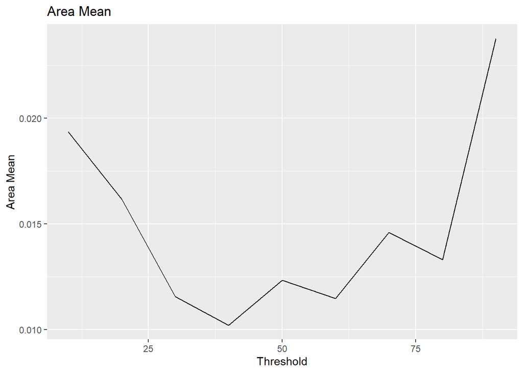

```r
LLthresh <- data.frame(threshold = c(10, 20, 30, 40, 50, 60, 70, 80, 90),
                        area_mn = c(0.01935, 0.01615631, 0.01155625, 0.0102092, 0.01232667, 0.01147655, 0.01459737, 0.0133128, 0.02377286),
                        np = c(86, 103, 144, 163, 135, 145, 114, 125, 70),
                        division = c(0.1933848, 0.3524663, 0.5263107, 0.6142139, 0.6520009, 0.6307496, 0.4831203, 0.3550903, 0.1880903))

plot_area_mn <- ggplot(LLthresh, aes(x = threshold, y = area_mn)) +
  geom_line() +
  labs(title = "Area Mean", x = "Threshold", y = "Area Mean")
plot_area_mn
```